# UML

## Diagramas de clases

### Clases

Una clase es el plan de construcción para un conjunto de objetos similares. Una clase puede caracterizar: personas, cosas, eventos, conceptos abstractos…

Un objeto representa una forma concreta de una clase. También recibe el nombre de instancia de una clase.

Las características de una instancia de una clase se describen mediante:

- **Atributos**: características estructurales (estado).
- **Operaciones**: características de comportamiento. Permiten comunicar los objetos unos con otros para actuar y reaccionar.

Ejemplo de clase *Course* modelado con UML y su correspondiente código Java.

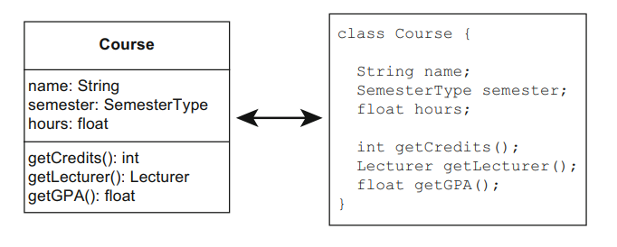

Imagen 1

#### Notación

En UML una clase se representa mediante una caja dividida en compartimentos -hasta 3 compartimentos:

- El ==1er compartimento== contiene el nombre de la clase en singular, centrado y en negrita.
- El ==2o compartimento== contiene los atributos de la clase, el estado.
- El ==3er compartimento== contiene las operaciones de la clase, el comportamiento.

El nivel de detalle del compartimento de atributos y operaciones depende de la fase de desarrollo en la que la clase se está analizando y del grado de abstracción con el que se quiera representar la clase.

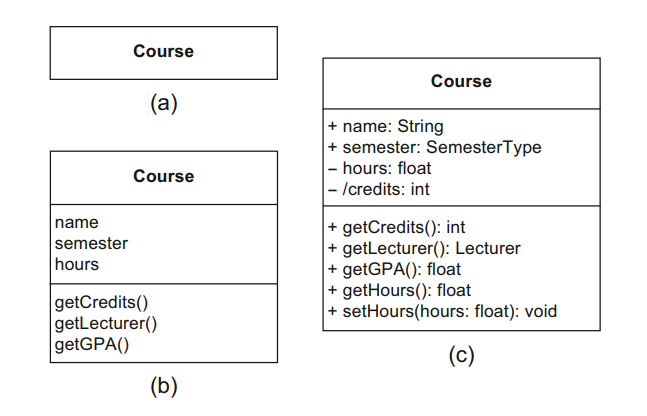

La representación (c) de *Course* sería más para una descripción de diseño, muy pormenorizada; mientras que (a) y (b) estarían más encaminadas a una fase de análisis más general, con menos detalle.

Atributos

Sintaxis:

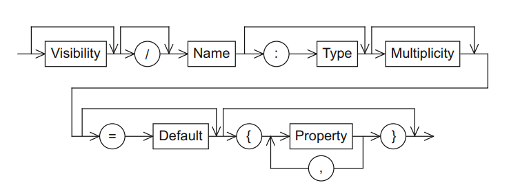

**Visibility Name: Type Multiplicity = Default {Property}**

Si desglosamos cada uno de los elementos de la sintaxis de atributo tenemos:

##### Visibilidad

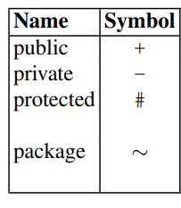

**public +**: cualquier clase puede acceder.

**private -:** sólo puede accederse desde la propia clase.

**protected #**: accesible desde la propia clase y cualquier subclase.

**package ~**: sólo accesible desde el mismo paquete.

**vacío** : visibilidad no especificada.

##### Derivado /

/age: int

age es un atributo derivado de dob (date of birth) y la fecha actual. Esto se indica mediante la barra /.

##### Nombre

Nombre del atributo, es decir, cómo la clase se refiere al atributo.

Ej:

firstName: String

dob: Date

En estos casos tenemos los nombres de: firstName y dob -preferiblemente, notación **Camel**.

##### Tipo

Restricción que indica qué tipo de objeto puede asignarse al atributo -como el tipo de un lenguaje de programación.

##### Multiplicidad

Sintaxis:

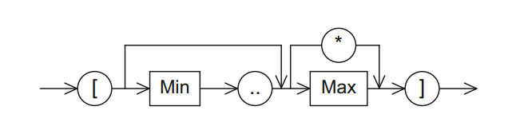

[minimum .. maximum]

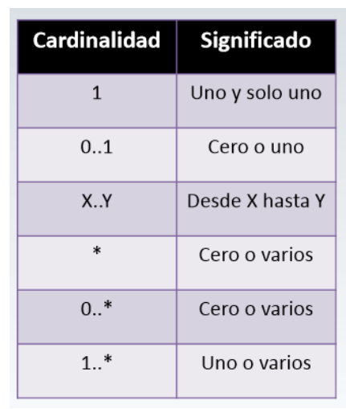

Indicación de cuántos objetos constituyen el atributo, propiedad o asociación entre clases.

Sobre el diagrama de ejemplo:

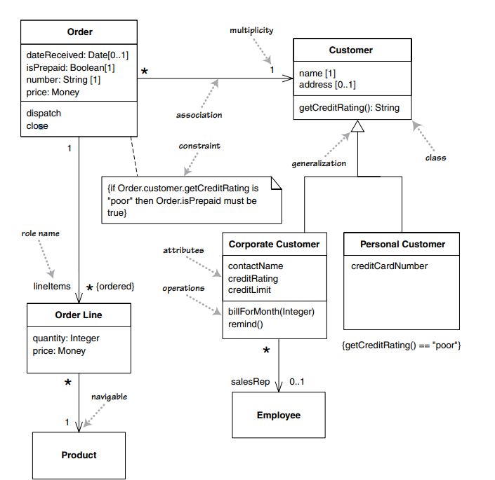

Las multiplicidades más comunes son:

• 1 (Un pedido (Order) debe tener exactamente un cliente (Customer)).

• 0..1 (Un cliente corporativo (Corporate Customer) puede o no tener un solo representante de ventas (Employee)).

• * (Un cliente no necesita realizar un pedido (Order) y no hay un límite superior para el número de pedidos que un cliente puede realizar: cero o más pedidos).

Si un atributo puede adoptar múltiples valores, tiene sentido especificar si el atributo es:

• Un conjunto (sin orden fijo de elementos, sin duplicados).

• Un conjunto múltiple (sin orden fijo de elementos, duplicados posibles)

• Un conjunto ordenado (orden fijo, sin duplicados)

• Una lista (orden fijo, posibles duplicados)

Puede realizar esta especificación combinando las propiedades {non-unique} {unique}, que definen si los duplicados están permitidos o no.

{ordered} {unordered} que fuerzan o cancelan un orden fijo de los valores de los atributos.

• Un conjunto (sin orden fijo de elementos, sin duplicados). → {unique, unordered} HashSet

• Un conjunto múltiple (sin orden fijo de elementos, duplicados posibles) → {non-unique, unordered} Bag

• Un conjunto ordenado (orden fijo, sin duplicados) → {unique, ordered} TreeSet

• Una lista (orden fijo, posibles duplicados)→ {nonunique, ordered} ArrayList

Ej:

address: String[1..*] {nonunique, ordered} ←→ Lista en lenguaje de programación de direcciones de una persona.

##### Valor por defecto =

Es el valor del atributo para una instancia nueva, en la que no se especifica su valor en el instante de creación -especificación para inicialización por defecto del atributo.

Ej:

password: String = “pw123”

En este ej. el valor por defecto de inicialización para el atributo password es “pw123”.

##### Propiedad

Para indicar propiedades adicionales para el atributo.

| Modifier | Description |
| --- | --- |
| id | identificador de la clase |
| readOnly | sólo lectura |
| ordered | ordenado |
| unique | atributo multivaluado que no tiene duplicados. |
| nonunique | atributo multivaluado que puede tener duplicados.. |
| sequence (or seq) | atributo bolsa ordenada (nonunique, ordered) |
| union | atributo derivado de la unión de sus subconjuntos |
| redefines property-name | atributo redefine el herada con nombre property-name |
| subsets property-name | atributo subconjunto del atribuyto con nombre property-name. |
| property-constraint | restricción que aplica al atributo |

Ej.

ssNo: String {readonly}

La propiedad de readonly establece que el atributo ssNo es sólo de lectura, una vez inicializado en la creación de la instancia.

address: String[1..*] {unique, ordered}

address será un conjunto de direcciones (sin duplicado) ordenado, con 1 dirección como mínimo.

##### Operaciones

Sintaxis:

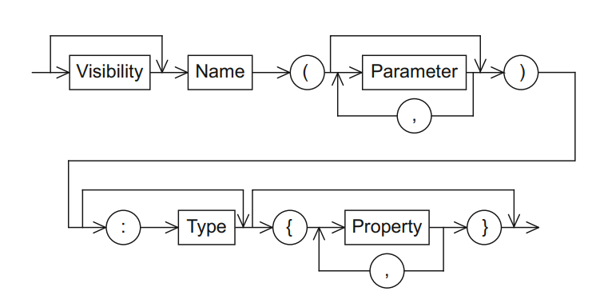

Visibility Name (Parameter-list) : Return-Type {Property-string}

Sintaxis de parámetro en operación:

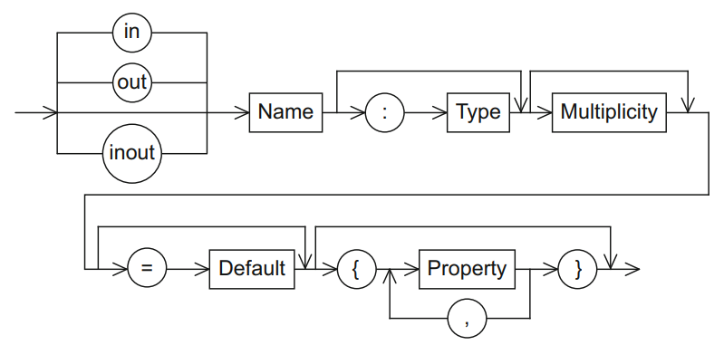

A lo ya visto en atributos, hay que añadir la dirección (in, out, inout) del parámetro que puede ser:

- in (por defecto): parámetro de entrada
- out: parámetro de salida
- inout: parámetro entrada/salida

Ej:

updateLastName(newName: String): boolean

El nombre de la operación será updateLastName. Tendrá sólo un parámetro de entrada (in) newName de tipo String. Y la operación devolverá el tipo boolean.

getName(out fn: String, out ln: String): void

El nombre de la operación será getName. Tendrá 2 parámetros de nombre fn y ln, ambos son parámetros con dirección de salida (out). La operación no devolverá nada.

Atributos/Operaciones estáticos _______

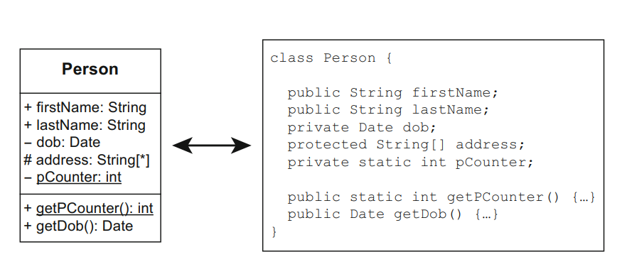

- pCounter: int es un atributo estático privado de tipo primitivo int, también llamado atributo de clase.

Este atributo no va a pertenecer a ninguna instancia de clase Person -sólo existe uno, exclusivo de la clase.

De ahí el nombre de atributo de clase, a diferencia de los otros atributos que recibirán el nombre de atributo de instancia, para los cuales cada una de las instancias tendrá un atributo diferente.

- getPCounter(): int es una operación estática, también conocida como operación de clase, es pública y devuelve un tipo primitivo int.

Igual que antes esta operación no va a pertenecer a ninguna instancia de clase Person y su ámbito -sólo existe uno, exclusivo de la clase. Por contraste las otras operaciones son operaciones de instancia.

#### Asociaciones

Las asociaciones entre clases modelan las posibles relaciones entre instancias de las clases.

Describen qué clases son partners potenciales de comunicación.

Si sus atributos y operaciones tienen las visibilidades apropiadas, estas instancias de partners de comunicación podrán acceder a los atributos y operaciones de su contrapartida.

Estas asociaciones se representan mediante líneas que unen las clases.

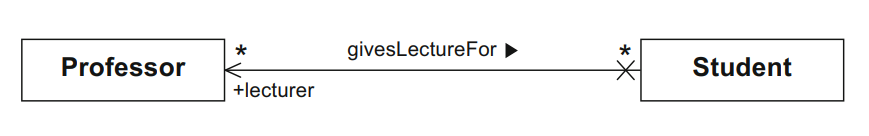

En este ejemplo, Professor tiene una asociación con Student (0 o muchos), que hemos nombrado con givesLectureFor (el triángulo sólido indica el sentido en que se lee).

En ambos extremos de la asociación tenemos una multiplicidad de * (0 o muchos).

Por otro lado, la flecha abierta indica la navegabilidad de la asociación de modo que Student puede acceder a Professor, y lo habrá etiquetado con +lecturer un atributo de visibilidad pública, entre sus atributos.

Por último, la x indica que no hay navegabilidad de Professor a Student, es decir Professor no puede acceder a instancias de Student.

##### Asociaciones binarias

Una asociación binaria nos permite asociar las instancias de 2 classes una con otra. La línea sólida que las une puede tener una etiqueta que será el nombre de la asociación con opcionalmente un triángulo sólido con el sentido de lectura.

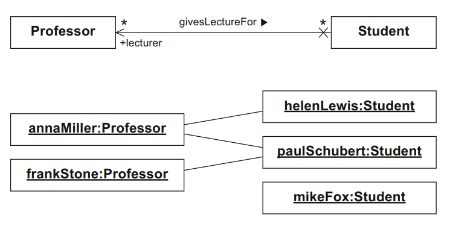

Navegabilidad

Si la línea de asociación es dirigida, es decir, que en uno de los extremos tenemos una cabeza de flecha abierta, entonces la navegación desde un objeto hacia su partner de comunicación es posible.

La navegabilidad va a indicar que un objeto conoce a su objeto partner y puede por tanto acceder a sus atributos y operaciones visibles.

En el ejemplo anterior, el nombre de asociación indica que el objeto/clase Profesor da clase a Estudiante (Professor gives lecture for Student), pero por la navegabilidad Student puede acceder a los atributos/operaciones de los Professor que le atienden. Por contra, un profesor no puede acceder a los atributos/operaciones de sus Student, al indicarse expresamente una x en el extremo de Student.

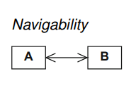

A puede acceder a B. Y B puede acceder a A.

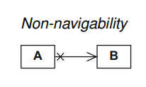

A puede acceder a B. Pero B no puede acceder a A.

Si no se indica cabeza de flecha <, > o x, entonces la navegabilidad se puede considerar que no está especificada (no se ha concretado, se abstrae del modelo). No obstante, en la práctica si no se especifica navegabilidad se asume que ambos extremos de la asociación son accesibles.

A continuación, se muestra la correspondencia de la asociación con navegabilidad (a) pasando al atributo la asociación (b) y el código Java correspondiente.

Destacar que (a) y (b) son representaciones equivalentes. No obstante, la representación con la línea de asociación es preferible dado que muestra esa asociación explícitamente.

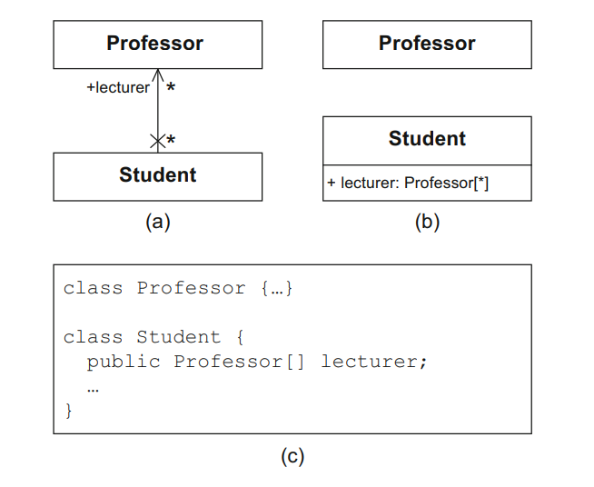

**Multiplicidad en la asociación**

De la misma manera que se especifica la multiplicidad de atributos y parámetros, se especifican las multiplicidades de las asociaciones mediante el intervalo:

minimum..maximum

La multiplicidad indica el número de objetos que pueden asociarse con exactamente un objeto del otro extremo de la asociación.

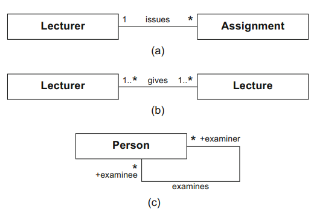

Estas multiplicidades se leerían como sigue:

- Lecturer → * Assignment: dado un Conferenciante (Lecturer) crea (issues) 0 o muchas Asignaciones (Assignment).

Lecturer 1 ← Assignment: dada una Asignación (Assignment) es creada por 1 solo Conferenciante (Lecturer).

- Lecturer → 1..* Lecture: dado un Conferenciante (Lecturer) da 1 o muchas Conferencias (Lecture).

Lecturer 1..* ← Lecture: dada una Conferencia (Lecture) es impartida por 1 o muchos Conferenciantes (Lecturer).

3. Person (+examiner) → * Person (+examinee): dado un examinador examina 0 o muchos examinados.

Person (+examiner) * ← Person (+examinee): dado un examinado es examinado por 0 o muchos examinadores.

##### Asociación Exclusiva

Para expresar que un objeto de clase A puede estar asociado con un objeto de clase B o un objeto de clase C, pero no ambos a la vez se especifica la restricción xor:

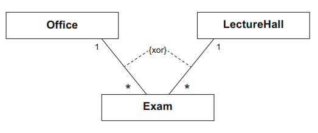

El Examen (Exam), o se realiza en la Oficina (Office), o se realiza en el Salón de Conferencias (LectureHall), pero no puede realizar en ambos a la vez (xor).

##### Asociación Ternaria (o n-aria)

Si tenemos que más de 2 objetos participan en una asociación entonces tendremos una asociación n-aria.

Las asociaciones n-arias se representan mediante un diamante hueco, con el diamante conectado a todos los partners de comunicación.

El nombre de la asociación se especifica sobre el diamante.

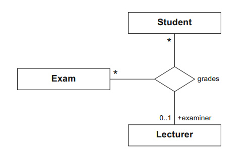

La forma de leer es tipo de asociación ternaria (n-aria) es:

- dado un estudiante (Student) y dado un examen (Exam), entonces 0 o 1 examinador (Lecturer) califica.
- dado un examen (Exam) y dado un examinador (Lecturer), entonces 0 o muchos estudiantes (Student) son calificados.
- dado un estudiante (Student) y dado un examinador (Lecturer), entonces 0 o muchos exámenes son calificados.

Si partimos una relación n-aria en relaciones binarias el significado será diferente:

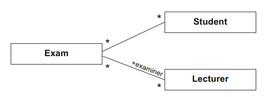

Con ambos modelos se puede expresar:

- un estudiante s1 tomó examen e1 con examinador l1, otro estudiante tomó el examen e1 con examinador l2.
- pero en el segundo no se expresa (explícitamente) qué examinador calificó al alumno.

Como alternativa a la relación ternaria se puede añadir una clase adicional de intersección (join):

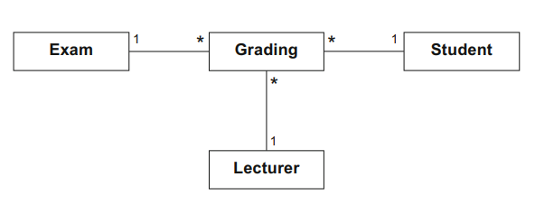

Este modelo equivalente a la relación ternaria añade una clase Grading, y lo leeríamos como:

- dada una calificación se corresponde con 1 examen, 1 examindador y 1 estudiante.

#### Clase de asociación

Asigna atributos o operaciones a la relación entre una o más clases, en vez de que aparezcan en las propias clases implicadas en la asociación. La asociación puede ser binaria o n-aria.

En la asociación entre las clases A y B tenemos una clase de asociación C con atributos y operaciones que no se han incluido ni en A ni en B.

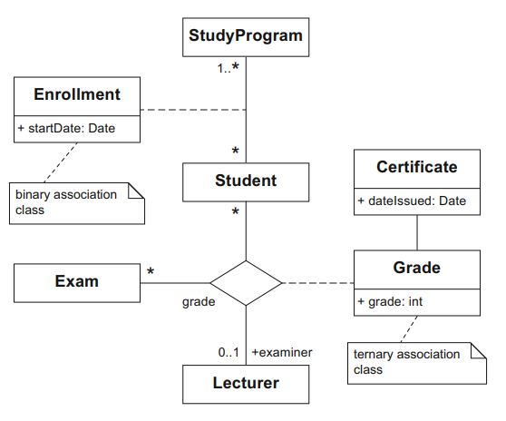

En general, no se puede reemplazar una clase de asociación con una clase “normal” asociada con sendas clases que participan en la asociación. El modelo resultante no tiene el mismo significado

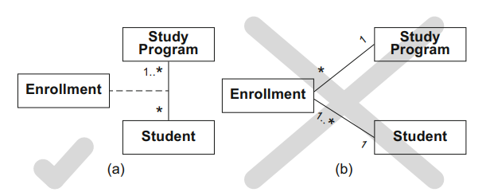

En el modelo (b) se permitiría que un estudiante (Student) tuviera varias matriculaciones (Enrollment) para un mismo programa de estudios (StudyProgram); mientras que en el modelo (a) un estudiante (Student) tiene una única matriculación (Enrollment) para un programa de estudios (StudyProgram).

Si se necesitan duplicados en la clase de asociación se utiliza la propiedad {non-unique}.

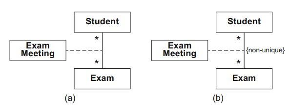

En el modelo (a) para un examen y estudiante sólo hay un intento (ExamMeeting), mientras que en el modelo (b) para un examen y un estudiante puede haber varios intentos.

#### Agregaciones

Forma especial de asociación utilizada para expresar que instancias de una clase son partes de una instancia de otra clase. Es una asociación transitiva y asimétrica.

Transitiva: si A es parte de B y B es parte de C, entonces A es parte de C.

Asimétrica: si A es parte de B, no puede darse que B sea parte de A.

UML diferencia 2 tipos:

- **Agregación (compartida)**: informal, expresa una pertenencia blanda de las partes al todo.

La multiplicidad en el extremo agregante puede ser mayor que 1 indicando que el agregado (parte) puede ser parte de varias agregantes (todos).

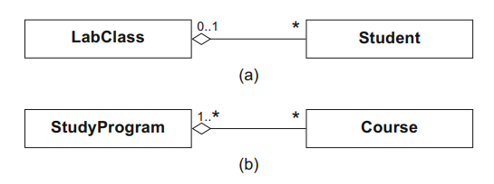

- **Composición**: expresa que una parte específica sólo puede ser contenida como máximo por 1 sólo objeto compuesto en un momento específico. La composición conlleva, por tanto, una multiplicidad máxima de 1 en el extremo agregante siempre.

Si el objeto compuesto (agregante, todo) se elimina, sus partes también se eliminan.

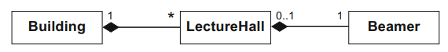

Un proyector dado, concreto, (*Beamer*) se encuentra sólo en 1 salón de conferencias, es decir, sólo puede formar parte de un salón (LectureHall) exclusivamente en un momento determinado (no puede estar en 2 salones simultáneamente, o ¿sí? 🙂)

Igualmente el salón (*LectureHall*) sólo puede formar parte de un edificio (*Building*).

Si se destruye el edificio (*Building*), se destruyen los salones (*LectureHall*) que lo forman, si se destruye un salón (*LectureHall*) se destruye el proyector (*Beamer*) que se encuentra en él.

Una asociación de composición se utiliza cuando las partes se encuentran físicamente en el objeto compuesto, o son sólo visibles para el objeto compuesto.

**Generalizaciones - Herencia**

Expresa que las características (atributos y operaciones) y asociaciones que son especificadas para una clase general (superclase) se pasan a sus subclases. Por tanto, la asociación de generalización también se conoce como herencia, o tipo de relación ES_UN (IS_A). Es una asociación transitiva.

A es un B, es decir, A hereda de B o A es subclase de la superclase B.

El nombre de la superclase debe elegirse de forma que cubra todas las subclases que heredan de ella

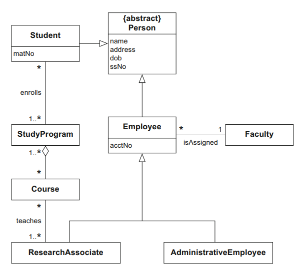

UML admite herencia múltiple, frente a implementaciones como Java que sólo tiene herencia simple.

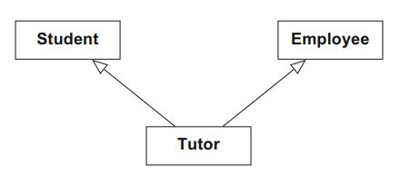

#### Clases Abstractas vs. Interfaces

##### Clases abstractas

Clases abstractas son clases que no pueden instanciarse. Para esas clases no hay objetos -sólo sus subclases pueden instanciarse. Útiles para destacar las características de sus subclases en un contexto de generalización o herencia.

Operaciones que no tienen una implementación en la clase abstracta se marcan como abstract, el resto de operaciones pasan sus implementaciones a sus subclases. Para que una subclase de una clase abstracta deje de ser abstracta debe implementar todas las operaciones marcadas como abstract.

También se puede representar una clase abstracta poniendo el nombre de la clase en cursiva. Son notaciones equivalentes:

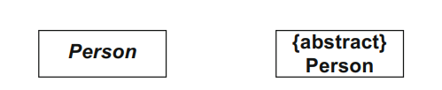